# Linear Model Analysis Project Report - Group 4

Authors

Duc Kien Doan

Nabat Isgandarova

Santiago Parra

Published

December 9, 2025

# 1 Introduction

This project examines the condition of various bridges in the US. The dataset has information about the bridge condition and some covariates that can help in explaining that condition. This report summarizes the process of exploratory data analysis (EDA), proposing a linear regression model with its interpretation and diagnostics, and finally make some prediction for new data. The variables in the dataset are as follows:

| **Variable** | **Description** |
| --- | --- |
| Structure_id | Identification key |
| `Urban` | Whether the bridge is in an urban or rural area |
| `Year` | The year the bridge was built |
| `Lanes_on` | Number of traffic lanes on the bridge |
| `AverageDaily` | The average daily traffic (number of vehicles) |
| `Historic` | Whether the bridge is historic |
| `Material` | The dominant material the bridge is made from |
| `Spans` | Number of spans of the bridge |
| `Length` | The length of the bridge (m) |
| `Width` | The width of the bridge (m) |
| `Trucks_percent` | The percentage of traffic made up of trucks |

# 2 Load packages

First, we load `tidyverse` packages, which serve as the workhorse of exploratory data analysis.

```r
library(tidyverse)
# Avoid displaying numbers in scientific notation
options(scipen=999)
```

# 3 Data Preparation

We now load the data, assuming that the two `.csv` files are in `data` folder. Based on the dataset description, we know that `Urban`, `Historic`, and `Material` are categorical covariates, which corresponds to `factor` in R.

```r
data <- read_csv("data/group_04.csv", col_types = cols(
  Urban = col_factor(),
  Historic = col_factor(),
  Material = col_factor(),
))
```

We now take a quick look at summary of the data. As we can see, there are 10 covariates, 3 of which are categorical.

```r
summary(data)
```

```
 Structure_id         Urban            Year         Lanes_on
 Length:30186       Rural:16343   Min.   :1900   Min.   : 1.00
 Class :character   Urban:13843   1st Qu.:1964   1st Qu.: 2.00
 Mode  :character                 Median :1985   Median : 2.00
                                  Mean   :1982   Mean   : 2.39
                                  3rd Qu.:2002   3rd Qu.: 2.00
                                  Max.   :2019   Max.   :15.00
  AverageDaily            Historic         Material         Spans
 Min.   :     0   Not historic:17549   Concrete:23888   Min.   :  0.000
 1st Qu.:   330   Possible    :12215   Timber  :  415   1st Qu.:  1.000
 Median :  3280   Register    :  373   Steel   : 5831   Median :  3.000
 Mean   : 11594   Unknown     :   49   Other   :   41   Mean   :  3.752
 3rd Qu.: 11850                        Masonry :   11   3rd Qu.:  4.000
 Max.   :543000                                         Max.   :194.000
     Length            Width        Trucks_percent     Condition
 Min.   :   6.10   Min.   :  2.50   Min.   : 0.000   Min.   : 0.0
 1st Qu.:  24.40   1st Qu.:  7.30   1st Qu.: 0.000   1st Qu.:19.0
 Median :  47.20   Median : 10.90   Median : 5.000   Median :21.0
 Mean   :  91.92   Mean   : 11.79   Mean   : 8.586   Mean   :20.3
 3rd Qu.:  87.80   3rd Qu.: 13.40   3rd Qu.:13.000   3rd Qu.:22.0
 Max.   :6270.30   Max.   :196.60   Max.   :99.000   Max.   :27.0
```

# 4 Exploratory Data Analysis

## 4.1 High level overview

### 4.1.1 Numerical covariates

We first take a look at the numeric covariates and their distribution. To achieve this, we plot their histograms.

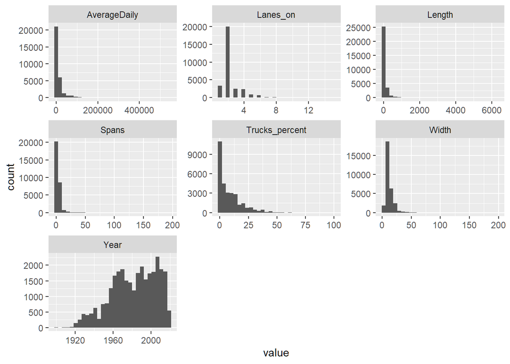

```r
data |>
  select(where(is.numeric), -c(Condition)) |>
  pivot_longer(everything(), names_to = "covariate") |>
  ggplot() +
  geom_histogram(aes(x=value)) +
  facet_wrap(~covariate, scales = "free", nrow=3)
```

From the plots, we can see that the distributions of the covariates are fairly skewed, especially `AverageDaily`, `Length`, `Width` and `Spans`, where the range of the values is very wide but most of them fall into a very small area, specifically near zero. This may require a log transformation to make the data more symmetrical.

We now focus our attention on the response variable, `Condition`, which deserves its own plot.

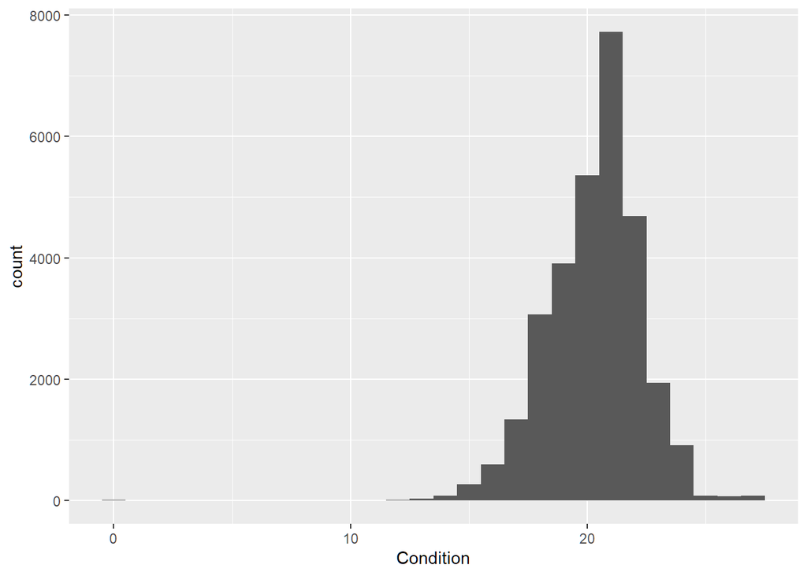

```r
data |>
  ggplot() +
  geom_histogram(aes(x = Condition), binwidth = 1)
```

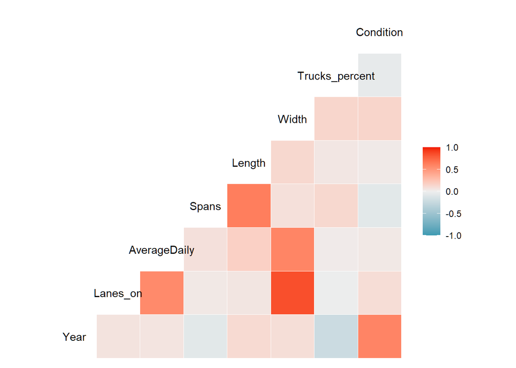

```r
GGally::ggcorr(data)
```

It can be seen that `Year` is the only covariate that has relatively high correlation with the response variable `Condition`. We expect that older bridges have worse condition than new ones, which we will inspect in the following sections.

As for the correlation between covariates, we notice that `Lanes_on` and `Width` has remarkably high positive correlation, while other pairs such as `Lanes_on` and `AverageDaily`, `Length` and `Spans` and `Width` and `AverageDaily` shows moderately positive correlation. On the other hand, `Year` and `Trucks_percent` has moderately negative correlation, indicating that more trucks cross older bridges.

### 4.1.2 Categorical covariates

There are three categorical covariates in the dataset, namely `Historic`, `Urban` and `Material`. First, we plot the heat map of counts for `Historic` and `Material` corresponding to the levels of `Urban`.

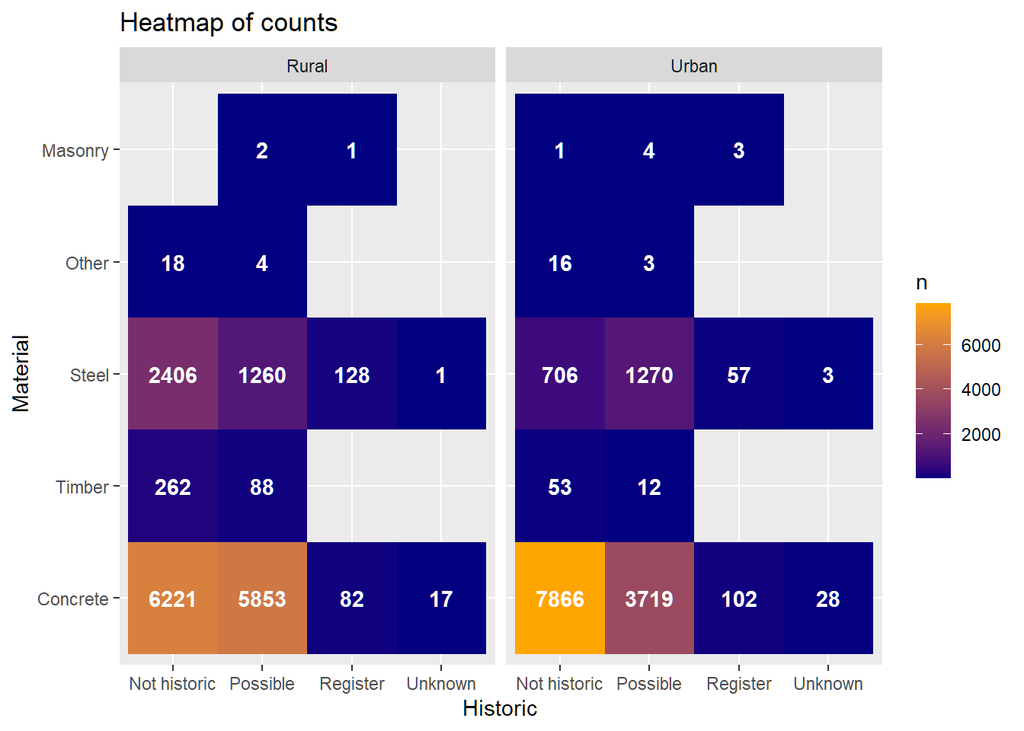

```r
data |>
  count(Historic, Material, Urban) |>
  ggplot(aes(x = Historic, y = Material, fill = n)) +
  geom_tile() +
  geom_text(aes(label = n), color = "white", fontface = "bold") +
  facet_grid(. ~ Urban) +
  scale_fill_gradient(low = "navy", high = "orange") +
  labs(title = "Heatmap of counts")
```

We now examine the categorical covariates and their relationship with the response variable.

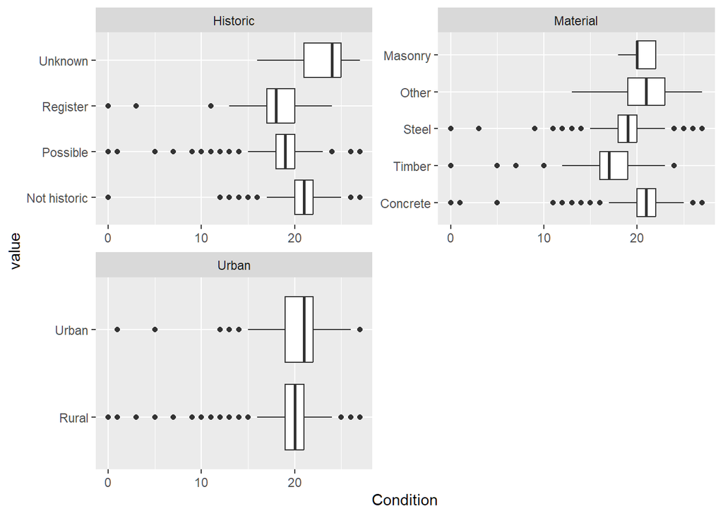

```r
data |>
  select(!where(is.numeric) & !Structure_id, Condition) |>
  pivot_longer(!Condition, names_to = "covariate", values_to = "value") |>
  ggplot() +
  geom_boxplot(aes(x = value, y = Condition)) +
  facet_wrap(~covariate, scales = "free", nrow = 2) +
  coord_flip()
```

## 4.2 Do newer bridges have better condition?

As suggested from the correlation matrix, we now plot the Year against the mean of Condition to verify if newer bridges really have better condition.

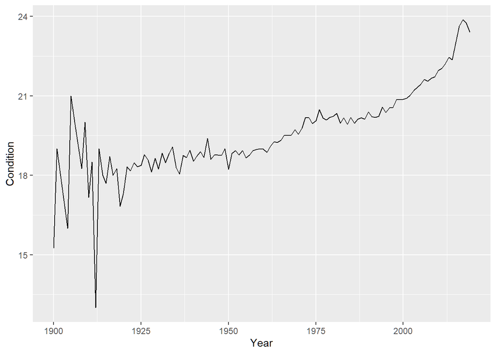

```r
data |>
  group_by(Year) |>
  summarize(Condition = mean(Condition)) |>
  ggplot(aes(x = Year, y = Condition)) +
  geom_line()
```

This confirms our expectation that bridges built more recently have better condition. However, we notice that the condition suddenly drops for bridges built between between 1900 and 1925. Perhaps we should examine what is going on in these years?

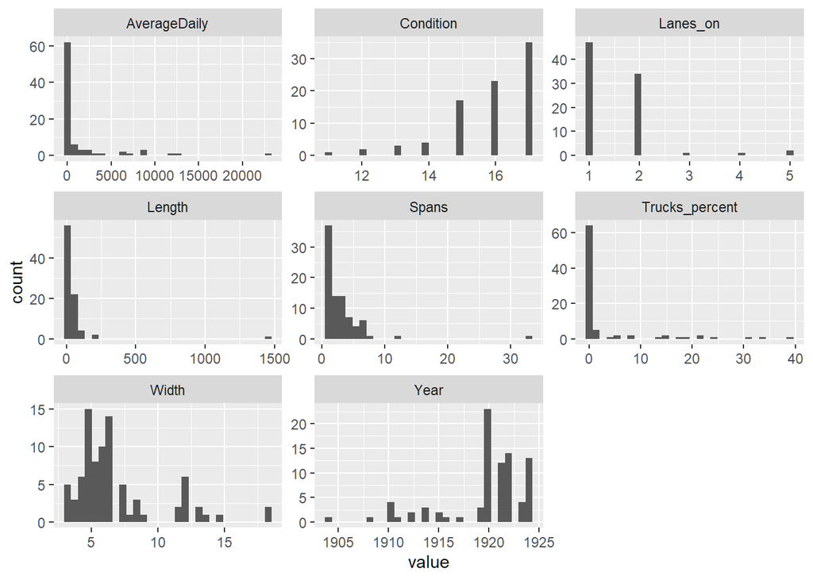

```r
data |>
  filter(Year > 1900, Year < 1925, Condition < 18) |>
  select(where(is.numeric)) |>
  pivot_longer(everything(), names_to = "covariate") |>
  ggplot() +
  geom_histogram(aes(x = value)) +
  facet_wrap(~covariate, scales = "free")
```

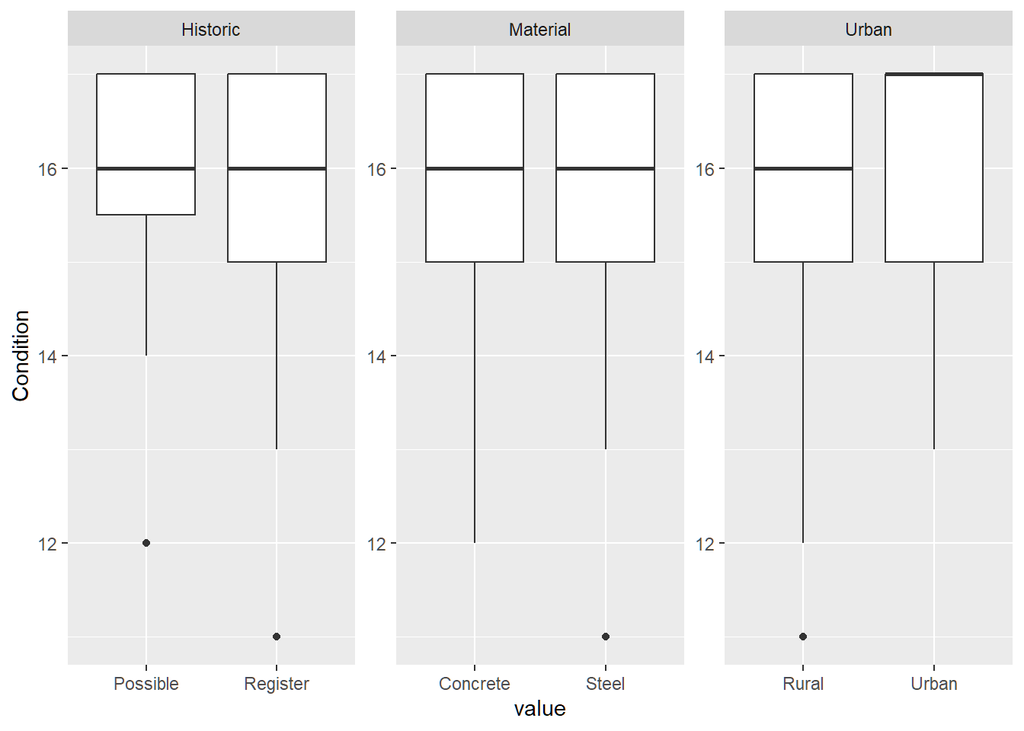

```r
data |>
  filter(Year > 1900, Year < 1925, Condition < 18) |>
  select(!where(is.numeric) & !Structure_id, Condition) |>
  pivot_longer(!Condition, names_to = "covariate", values_to = "value") |>
  ggplot() +
  geom_boxplot(aes(x = value, y = Condition)) +
  facet_wrap(~covariate, scales = "free")
```

# 5 Methods

## 5.1 Multiple linear regression with all covariates, no interaction

### 5.1.1 Model fitting

We first fit a standard linear regression model using all the covariates, where the categorical covariates are coded using dummy variables.

```r
model <- lm(Condition ~ ., data = select(data, -Structure_id))
summary(model)
```

```
Call:
lm(formula = Condition ~ ., data = select(data, -Structure_id))

Residuals:
     Min       1Q   Median       3Q      Max
-19.9738  -0.8218   0.0749   0.8810   7.3788

Coefficients:
                       Estimate     Std. Error t value             Pr(>|t|)
(Intercept)      -83.8721300686   1.3469079540 -62.270 < 0.0000000000000002 ***
UrbanUrban        -0.0240872261   0.0198653386  -1.213             0.225321
Year               0.0526592568   0.0006738529  78.147 < 0.0000000000000002 ***
Lanes_on          -0.0483204165   0.0136733088  -3.534             0.000410 ***
AverageDaily      -0.0000024553   0.0000004526  -5.425   0.0000000582650405 ***
HistoricPossible   0.2885191598   0.0321982672   8.961 < 0.0000000000000002 ***
HistoricRegister   0.4315630012   0.0869045126   4.966   0.0000006874030085 ***
HistoricUnknown    1.3402306777   0.2095953217   6.394   0.0000000001635638 ***
MaterialTimber    -3.2040047419   0.0735426097 -43.567 < 0.0000000000000002 ***
MaterialSteel     -1.3756607385   0.0231451182 -59.436 < 0.0000000000000002 ***
MaterialOther     -0.2911182560   0.2289257808  -1.272             0.203500
MaterialMasonry    2.3014771210   0.4426324002   5.200   0.0000002011029420 ***
Spans             -0.0356265471   0.0022963072 -15.515 < 0.0000000000000002 ***
Length             0.0002745980   0.0000641200   4.283   0.0000185322369869 ***
Width              0.0211512727   0.0027569267   7.672   0.0000000000000174 ***
Trucks_percent     0.0030665617   0.0009220378   3.326             0.000883 ***
---
Signif. codes:  0 '***' 0.001 '**' 0.01 '*' 0.05 '.' 0.1 ' ' 1

Residual standard error: 1.464 on 30170 degrees of freedom
Multiple R-squared:  0.4652,    Adjusted R-squared:  0.4649
F-statistic:  1750 on 15 and 30170 DF,  p-value: < 0.00000000000000022
```

### 5.1.2 Model interpretation

- An $R^2$ value of 0.4652 means that the model is only able to explain 46.52% of the variance in the response.
- The low p-value for the F-statistic suggests that the model helps explain some of the variance compared to the null model.
- As for the covariates:
  - We first call our attention to the high p-values of coefficients corresponding to `Urban` level of `Urban` covariate and `Other` level of `Material` covariate. High p-values suggest that we should retain the null hypothesis that their coefficient is zero. In the context of dummy variable coding, this means that there is no significant change in the response (`Condition`) when we move from the reference level (in this case, `Rural` and `Concrete` respectively) to the corresponding level (`Urban` and `Other`). This is also reflected in the exploratory data analysis plots earlier.
  - Despite having very low p-values, which means *statistical significance*, some covariates, namely `AverageDaily`, `Length`, `Width`, `Spans` and `Trucks_percent` have very small coefficients (and also very small standard error, which leads to low p-values). We can further examine this by computing the confidence intervals for each covariate.

```r
confint(model)
```

```
                            2.5 %           97.5 %
(Intercept)      -86.512127060563 -81.232133076609
UrbanUrban        -0.063024136340   0.014849684138
Year               0.051338476436   0.053980037126
Lanes_on          -0.075120684525  -0.021520148494
AverageDaily      -0.000003342389  -0.000001568301
HistoricPossible   0.225409183946   0.351629135750
HistoricRegister   0.261226452902   0.601899549575
HistoricUnknown    0.929414914719   1.751046440702
MaterialTimber    -3.348151391194  -3.059858092702
MaterialSteel     -1.421026156515  -1.330295320438
MaterialOther     -0.739822542597   0.157586030641
MaterialMasonry    1.433898752659   3.169055489397
Spans             -0.040127407136  -0.031125687129
Length             0.000148920088   0.000400275941
Width              0.015747578806   0.026554966497
Trucks_percent     0.001259328406   0.004873794982
```

Due to these small coefficients, `AverageDaily`, `Length`, `Width`, `Spans` and `Trucks_percent` may not contribute very much to the model, unless their values are large enough. This is indeed the case for some observations when we look at the histograms in the exploratory data analysis section. Therefore, these extremely high values could be influential to the model, which is examined in the next section.

### 5.1.3 Model diagnostics

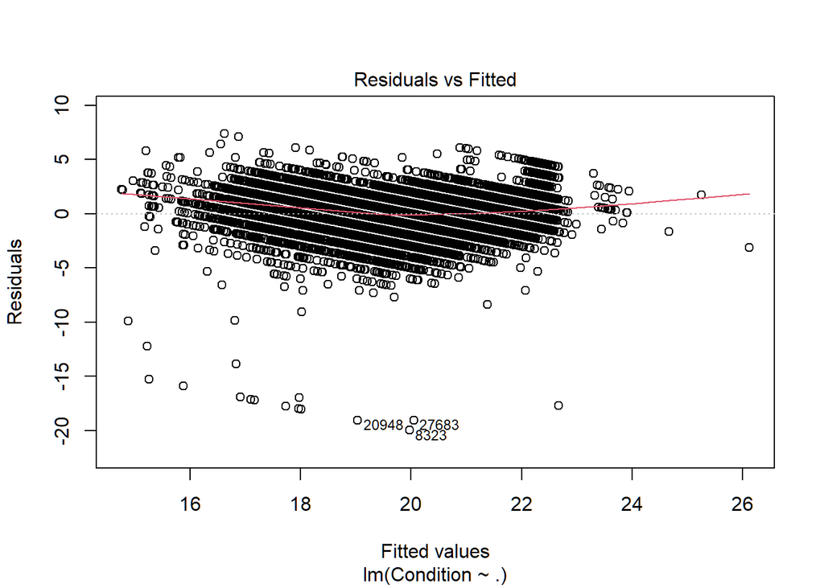

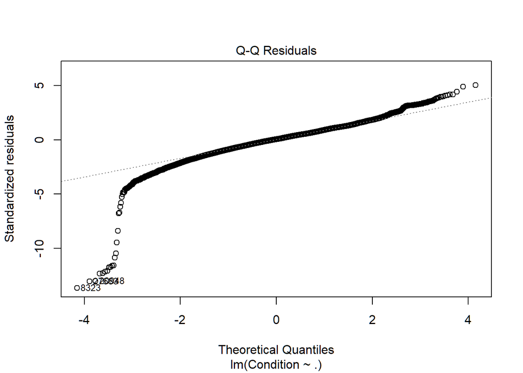

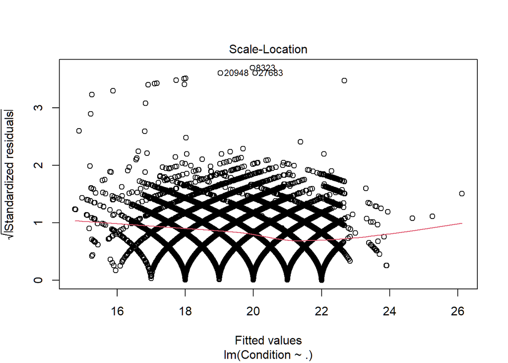

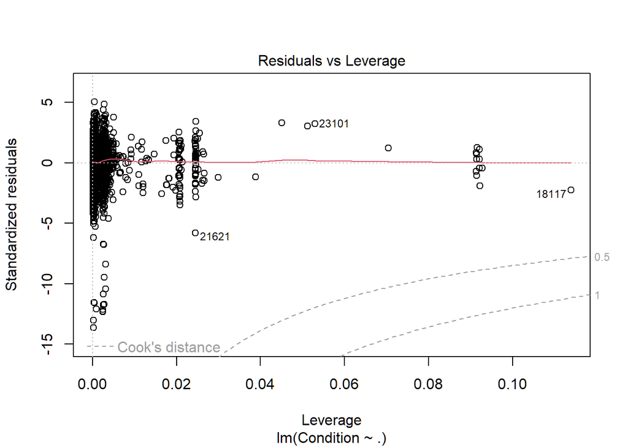

```r
plot(model)
```

## 5.2 Multiple linear regression after transforming data

```r
model2 <- lm(Condition ~ Urban + Historic + Material + Year + Lanes_on + log(AverageDaily + 1) + log(Spans + 1) + log(Length + 1) + log(Width + 1) + Trucks_percent, data = select(data, -Structure_id))
summary(model2)
```

```
Call:
lm(formula = Condition ~ Urban + Historic + Material + Year +
    Lanes_on + log(AverageDaily + 1) + log(Spans + 1) + log(Length +
    1) + log(Width + 1) + Trucks_percent, data = select(data,
    -Structure_id))

Residuals:
     Min       1Q   Median       3Q      Max
-19.8340  -0.8156   0.0776   0.8869   7.5297

Coefficients:
                         Estimate  Std. Error t value             Pr(>|t|)
(Intercept)           -81.4256036   1.3696331 -59.451 < 0.0000000000000002 ***
UrbanUrban             -0.1115946   0.0235594  -4.737       0.000002181679 ***
HistoricPossible        0.2849290   0.0319556   8.916 < 0.0000000000000002 ***
HistoricRegister        0.4313385   0.0869625   4.960       0.000000708560 ***
HistoricUnknown         1.3699125   0.2079104   6.589       0.000000000045 ***
MaterialTimber         -3.0228042   0.0739576 -40.872 < 0.0000000000000002 ***
MaterialSteel          -1.3591168   0.0231784 -58.637 < 0.0000000000000002 ***
MaterialOther          -0.2907188   0.2272621  -1.279               0.2008
MaterialMasonry         2.1428633   0.4395520   4.875       0.000001093015 ***
Year                    0.0508878   0.0006878  73.992 < 0.0000000000000002 ***
Lanes_on               -0.1708259   0.0123116 -13.875 < 0.0000000000000002 ***
log(AverageDaily + 1)  -0.0040905   0.0066904  -0.611               0.5409
log(Spans + 1)         -0.4067270   0.0217312 -18.716 < 0.0000000000000002 ***
log(Length + 1)         0.0443643   0.0142089   3.122               0.0018 **
log(Width + 1)          0.7940716   0.0463382  17.136 < 0.0000000000000002 ***
Trucks_percent         -0.0013379   0.0009810  -1.364               0.1726
---
Signif. codes:  0 '***' 0.001 '**' 0.01 '*' 0.05 '.' 0.1 ' ' 1

Residual standard error: 1.453 on 30170 degrees of freedom
Multiple R-squared:  0.4731,    Adjusted R-squared:  0.4728
F-statistic:  1806 on 15 and 30170 DF,  p-value: < 0.00000000000000022
```

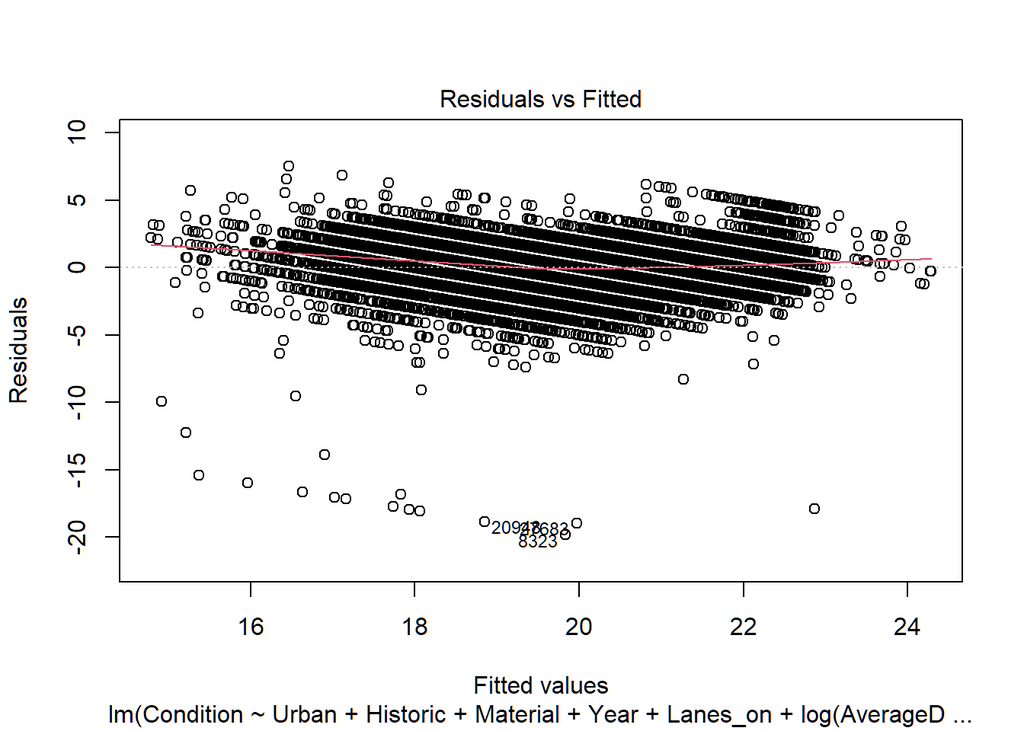

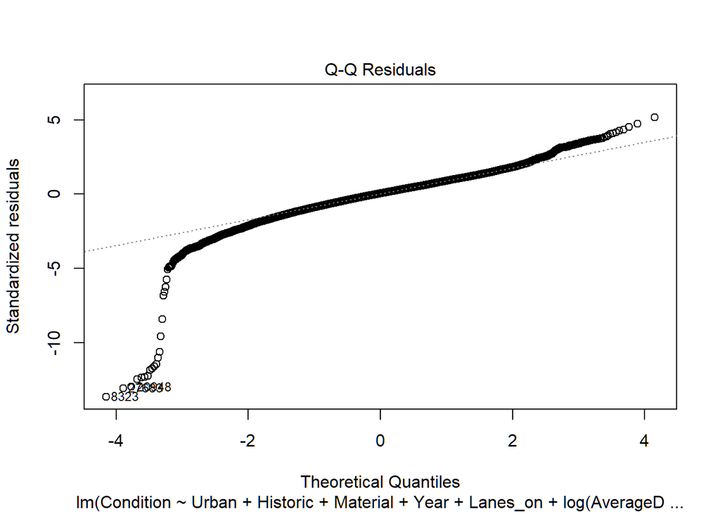

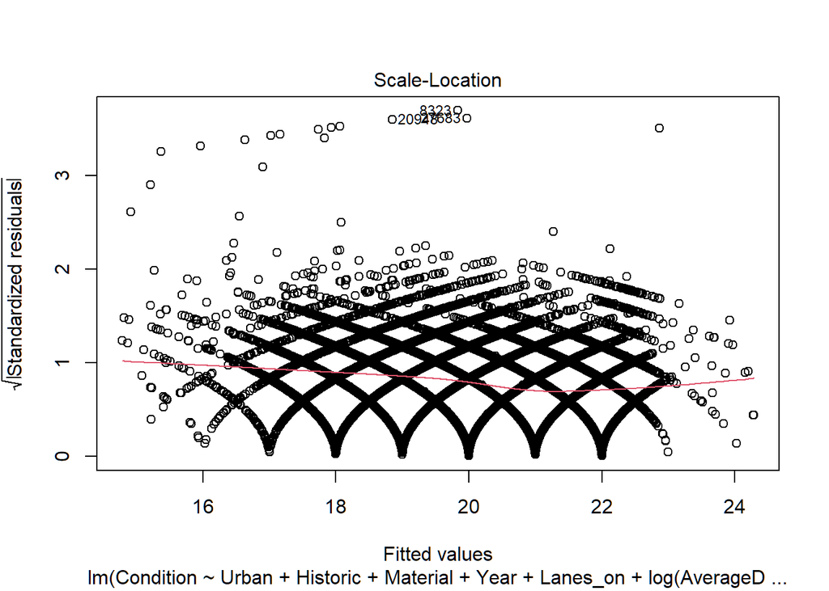

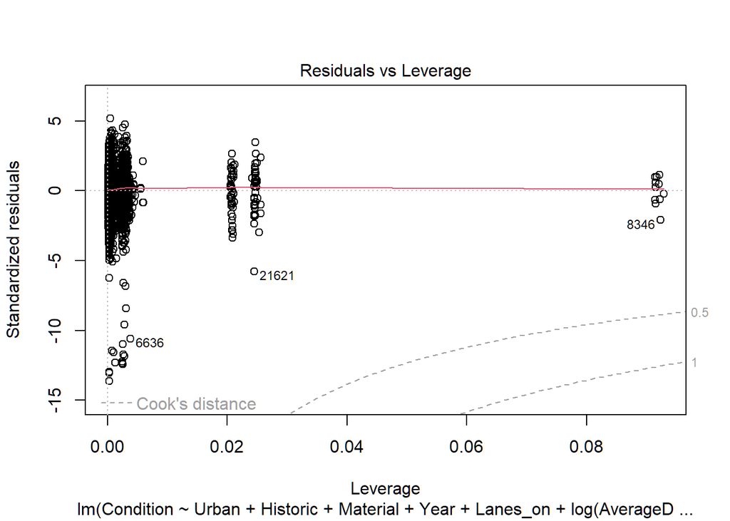

```r
plot(model2)
```